# Reproducible Research: Peer Assessment 1

## Loading and preprocessing the data

```r
library(dplyr)
```

```r
library(ggplot2)
# unzip file if necessary
if(!file.exists("activity.csv")) {
  unzip ("activity.zip", exdir=".")
}
activity <- read.csv("activity.csv", na.strings="NA")
```

## What is the mean total number of steps taken per day?

We group the activity by day (‘date’ is a factor here) and calculate the sum of steps for each day:

```r
activity.day <- group_by(activity, date)
activity.day.total <- summarise(activity.day, sum(steps))
```

This gives us the following histogram:

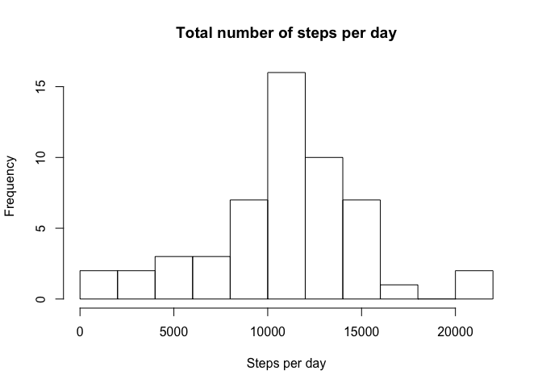

```r
names(activity.day.total) <- c('date', 'total.steps')
hist(activity.day.total$total.steps, breaks=8,
     main="Total number of steps per day", xlab="Steps per day")
```

### Mean and median

```r
steps.mean <- format(mean(activity.day.total$total.steps, na.rm=TRUE),
                     scientific=F)
steps.mean
```

```
## [1] "10766.19"
```

```r
steps.median <- format(median(activity.day.total$total.steps, na.rm=TRUE),
                       scientific=F)
steps.median
```

```
## [1] "10765"
```

The mean of the total number of steps taken per day is **10766.19** and the median is **10765**.

## What is the average daily activity pattern?

The average daily activity pattern looks as follows:

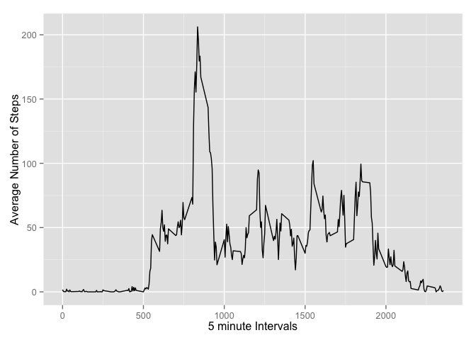

```r
activity.timeseries <- group_by(activity, interval)
activity.timeseries.mean <- summarise(activity.timeseries, mean(steps,
                                                                na.rm=TRUE))
names(activity.timeseries.mean) <- c('interval', 'steps.mean')
ggplot(activity.timeseries.mean, aes(interval, steps.mean)) +
  geom_line() +
    xlab("5 minute Intervals") +
    ylab("Average Number of Steps")
```

```r
max.steps <- max(activity.timeseries.mean$steps.mean)
activity.timeseries.mean.sorted <-
  activity.timeseries.mean[rev(order(activity.timeseries.mean$steps.mean)),]
max.steps.interval <- activity.timeseries.mean.sorted[1,1]
max.steps.interval
```

```
## Source: local data frame [1 x 1]
##
##   interval
##      (int)
## 1      835
```

On average across all the days in the dataset, the highest number of steps (206.1698113) is taken in interval **835**.

## Imputing missing values

Calculating the missing values for each column, we see that only the ‘steps’ column is missing data:

```r
apply(is.na(activity),2,sum)
```

```
##    steps     date interval
##     2304        0        0
```

To fill in the missing data, we add the mean number of steps per interval for every interval that is missing data (calculated and stored in the `activity.timeseries.mean` dataframe in the previous section):

```r
activity.nomissing <- cbind(activity,activity.timeseries.mean[2])
activity.nomissing$steps[is.na(activity.nomissing$steps)] <-
  activity.nomissing$steps.mean[is.na(activity.nomissing$steps)]
drop <- c('steps.mean')
activity.nomissing <- activity.nomissing[,!names(activity.nomissing) %in% drop]
```

This gives us a dataframe with no missing data:

```r
apply(is.na(activity.nomissing),2,sum)
```

```
##    steps     date interval
##        0        0        0
```

### Plotting the histogram for filled in data

We now follow the same procedure as in the first section, first grouping the activity by day (‘date’ is again a factor) and calculating the sum of steps for each day:

```r
activity.nomissing.day <- group_by(activity.nomissing, date)
activity.nomissing.day.total <- summarise(activity.nomissing.day, sum(steps))
```

This gives us the following histogram:

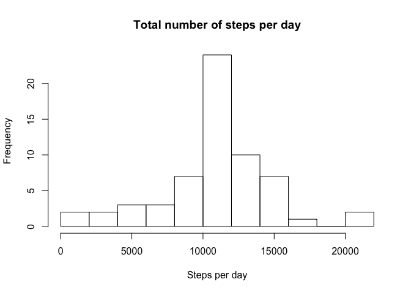

```r
names(activity.nomissing.day.total) <- c('date', 'total.steps')
hist(activity.nomissing.day.total$total.steps, breaks=8,
     main="Total number of steps per day", xlab="Steps per day")
```

### Mean and median with filled in data

```r
steps.mean.nomissing <- format(mean(activity.nomissing.day.total$total.steps),
                               scientific=F)
steps.mean.nomissing
```

```
## [1] "10766.19"
```

```r
steps.median.nomissing <- format(median(activity.nomissing.day.total$total.steps),
                                 scientific=F)
steps.median.nomissing
```

```
## [1] "10766.19"
```

The mean of the total number of steps taken per day when data has been filled in is **10766.19** and the median is **10766.19**. Note that the mean is **exactly the same** as before after this operation, but the median is now ever so slightly higher - indeed it has become **equal to the mean**.

## Are there differences in activity patterns between weekdays and weekends?

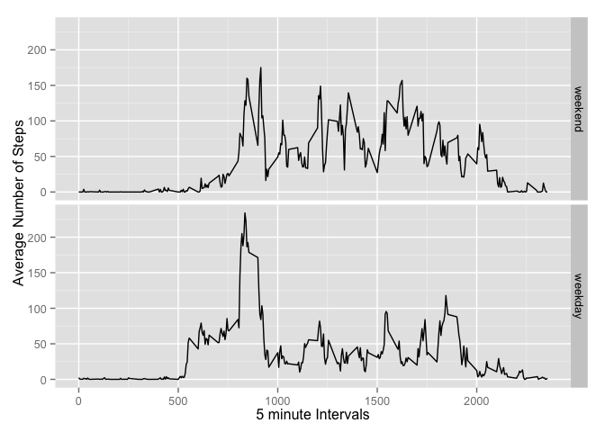

```r
activity$date <- strptime(activity$date, format="%Y-%m-%d")
weekdays <- c('Monday', 'Tuesday', 'Wednesday', 'Thursday', 'Friday')
activity$time.of.week <- factor((weekdays(activity$date) %in% weekdays),
                                levels=c(FALSE, TRUE),
                                labels=c('weekend', 'weekday'))
activity$date <- as.character(activity$date)
activity.wday <- group_by(activity, interval, time.of.week)
activity.wday.timeseries.mean <- summarise(activity.wday, mean(steps,
                                                               na.rm=TRUE))
names(activity.wday.timeseries.mean) <- c('interval', 'time.of.week',
                                          'steps.mean')

ggplot(activity.wday.timeseries.mean, aes(as.integer(interval), steps.mean)) +
    geom_line() +
    xlab("5 minute Intervals") +
    ylab("Average Number of Steps") +
    facet_grid(time.of.week ~ .)
```

From this plot we can see that there is more general activity throughout the day in weekends, whereas weekdays are characterized by an activity spike in the morning and less activity later in the day.